# WorkshopDNADNA

## Plot results on test sets

```python
def plot_scenario(scn, df, ax=None, c="k"):
    """
    plot all replicates (if present) of the prediction for a given scenario
    """
    if ax is None:
        fig, ax = plt.subplots(1, 1, figsize=(8, 5))
    df = df.loc[scn]
    if isinstance(df, pd.Series):
        ax.plot(df, c, lw=1)
    else:
        for r in df.loc[scn].iterrows():
            ax.plot(r[1].drop("path"), c, lw=0.5, alpha=0.4)
    ax.plot(df_param.loc[scn].filter(regex="T\w{2}"), "k", lw=1)
```

```python
random_test_scenarios = np.random.choice(df_san.index.unique(), size=9)
```

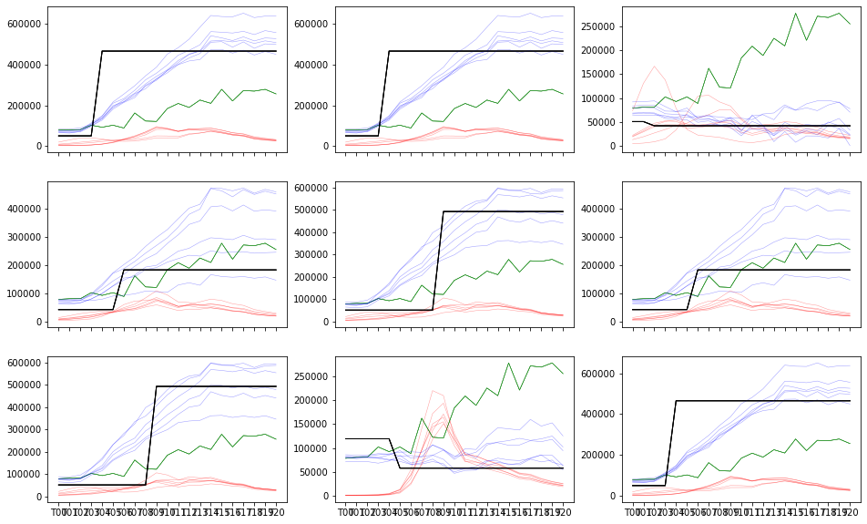

```python
fig, axs = plt.subplots(3, 3, figsize=(16, 10), sharex=True)
ax = axs.ravel()
for i, si in enumerate(random_test_scenarios):
    plot_scenario(si, df_best, c="green", ax=ax[i])
    plot_scenario(si, df_san, c="red", ax=ax[i])
    plot_scenario(si, df_large, c="blue", ax=ax[i])
```

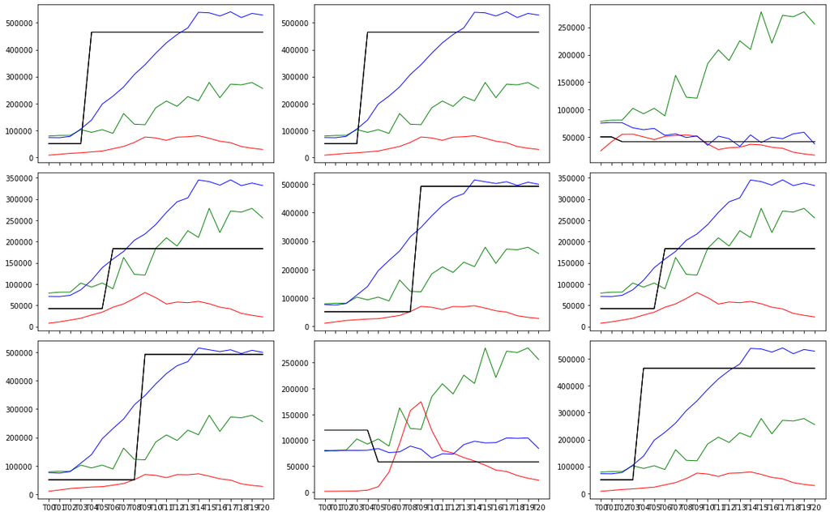

```python
fig, axs = plt.subplots(3, 3, figsize=(16, 10), sharex=True)
ax = axs.ravel()
for i, si in enumerate(random_test_scenarios):
    plot_scenario(si, df_best.groupby("scenario_idx").mean(), c="green", ax=ax[i])
    plot_scenario(si, df_san.groupby("scenario_idx").mean(), c="red", ax=ax[i])
    plot_scenario(si, df_large.groupby("scenario_idx").mean(), c="blue", ax=ax[i])
plt.tight_layout()
```

**What could cause the poor performance when reusing the pre-trained SPIDNA network (Sanchez) ?**

**Can you check whether selection affects the results ?** `df_all_param` has information for each scenario as to whether there is selection or not

```python
df_all_param.head()
```

| scenario_idx | mu | geneconv_ratio | len_conv | chr_size | Ne | N_generations | T_bottleneck | strength_bottleneck | coeff_sel | Tstart_sweep | selection | model_init | n_replicates |
| --- | --- | --- | --- | --- | --- | --- | --- | --- | --- | --- | --- | --- | --- |
| 1 | 5.750000e-10 | 0.215443 | 122000.0 | 2065000.0 | 117090.909091 | 21900.0 | 4689.655172 | 0.274194 | NaN | NaN | False | BottleneckNoselection-015 | 5 |
| 8 | 1.168750e-09 | 0.011860 | 122000.0 | 2065000.0 | 105636.363636 | 21900.0 | 13206.896552 | 0.535484 | NaN | NaN | False | BottleneckNoselection-015 | 5 |
| 15 | 1.593750e-10 | 0.153174 | 122000.0 | 2065000.0 | 132710.743802 | 21900.0 | 2448.275862 | 0.912903 | NaN | NaN | False | BottleneckNoselection-015 | 5 |
| 18 | 1.584375e-09 | 0.065285 | 122000.0 | 2065000.0 | 41074.380165 | 21900.0 | 5137.931034 | 0.622581 | NaN | NaN | False | BottleneckNoselection-015 | 5 |
| 21 | 8.718750e-10 | 0.108902 | 122000.0 | 2065000.0 | 23371.900826 | 21900.0 | 5586.206897 | 0.419355 | NaN | NaN | False | BottleneckNoselection-015 | 5 |

```python
df_best2 = df_best.merge(df_all_param[["selection"]], left_index=True, right_index=True)
```

```python
df_best2
```

| scenario_idx | T00 | T01 | T02 | T03 | T04 | T05 | T06 | T07 | T08 | T09 | ... | T13 | T14 | T15 | T16 | T17 | T18 | T19 | T20 | path | selection |
| --- | --- | --- | --- | --- | --- | --- | --- | --- | --- | --- | --- | --- | --- | --- | --- | --- | --- | --- | --- | --- | --- |
| 1304 | 78727.804688 | 80865.695312 | 80994.570312 | 102448.765625 | 92654.265625 | 102461.296875 | 88719.328125 | 162496.281250 | 122815.367188 | 121082.820312 | ... | 225587.625000 | 209602.343750 | 278175.06250 | 221246.828125 | 271858.25000 | 269227.28125 | 278125.00000 | 255698.890625 | DataWorkshop_DNADNA/scenario_01304/BacterialDe... | False |
| 1304 | 78733.593750 | 80872.101562 | 80997.437500 | 102431.953125 | 92693.812500 | 102437.507812 | 88706.562500 | 162545.250000 | 122795.546875 | 121052.023438 | ... | 225553.953125 | 209508.468750 | 278147.96875 | 221181.671875 | 271898.00000 | 269246.53125 | 278086.12500 | 255658.265625 | DataWorkshop_DNADNA/scenario_01304/BacterialDe... | False |
| 1304 | 78725.703125 | 80861.210938 | 80999.867188 | 102451.828125 | 92687.882812 | 102446.367188 | 88744.250000 | 162484.468750 | 122860.031250 | 121117.250000 | ... | 225400.468750 | 209527.890625 | 278215.03125 | 221240.031250 | 271804.21875 | 269052.90625 | 278098.93750 | 255733.406250 | DataWorkshop_DNADNA/scenario_01304/BacterialDe... | False |
| 1304 | 78723.476562 | 80872.757812 | 80996.609375 | 102465.476562 | 92670.281250 | 102469.960938 | 88678.375000 | 162457.031250 | 122800.945312 | 121095.859375 | ... | 225561.812500 | 209538.156250 | 278143.81250 | 221156.562500 | 271827.12500 | 269277.46875 | 278133.18750 | 255721.125000 | DataWorkshop_DNADNA/scenario_01304/BacterialDe... | False |
| 1304 | 78732.140625 | 80868.851562 | 80990.859375 | 102461.328125 | 92669.835938 | 102467.804688 | 88730.445312 | 162505.468750 | 122735.671875 | 121061.703125 | ... | 225496.046875 | 209526.687500 | 278172.46875 | 221176.421875 | 271874.56250 | 269093.59375 | 278120.90625 | 255665.187500 | DataWorkshop_DNADNA/scenario_01304/BacterialDe... | False |
| 1304 | 78739.234375 | 80866.820312 | 80986.156250 | 102431.343750 | 92679.015625 | 102459.265625 | 88727.875000 | 162463.843750 | 122770.539062 | 121102.632812 | ... | 225581.546875 | 209563.656250 | 278178.56250 | 221243.609375 | 271845.09375 | 269230.84375 | 278094.31250 | 255669.984375 | DataWorkshop_DNADNA/scenario_01304/BacterialDe... | False |
| 2710 | 78726.195312 | 80879.000000 | 80998.039062 | 102441.820312 | 92669.859375 | 102478.203125 | 88718.296875 | 162477.156250 | 122822.632812 | 121065.125000 | ... | 225582.984375 | 209610.703125 | 278119.40625 | 221218.250000 | 271842.00000 | 269258.43750 | 278063.84375 | 255676.500000 | DataWorkshop_DNADNA/scenario_02710/BacterialDe... | True |
| 2710 | 78732.203125 | 80881.218750 | 80997.781250 | 102450.921875 | 92680.046875 | 102488.000000 | 88715.265625 | 162496.781250 | 122824.859375 | 121050.781250 | ... | 225597.406250 | 209574.156250 | 278054.43750 | 221187.312500 | 271859.31250 | 269300.65625 | 278046.65625 | 255650.828125 | DataWorkshop_DNADNA/scenario_02710/BacterialDe... | True |
| 2710 | 78732.218750 | 80875.562500 | 80998.203125 | 102443.437500 | 92666.882812 | 102476.671875 | 88724.000000 | 162482.312500 | 122831.773438 | 121073.351562 | ... | 225616.359375 | 209592.375000 | 278089.78125 | 221202.562500 | 271864.25000 | 269288.09375 | 278067.96875 | 255674.203125 | DataWorkshop_DNADNA/scenario_02710/BacterialDe... | True |
| 2710 | 78732.273438 | 80873.695312 | 80990.632812 | 102450.640625 | 92651.921875 | 102480.937500 | 88739.601562 | 162477.531250 | 122825.156250 | 121053.179688 | ... | 225573.296875 | 209555.093750 | 278128.87500 | 221216.875000 | 271846.59375 | 269210.84375 | 278085.18750 | 255679.140625 | DataWorkshop_DNADNA/scenario_02710/BacterialDe... | True |
| 2710 | 78728.109375 | 80883.718750 | 81000.375000 | 102440.085938 | 92665.367188 | 102491.984375 | 88715.320312 | 162491.921875 | 122816.679688 | 121023.835938 | ... | 225587.437500 | 209576.984375 | 278078.06250 | 221177.296875 | 271843.25000 | 269257.75000 | 278034.18750 | 255664.750000 | DataWorkshop_DNADNA/scenario_02710/BacterialDe... | True |
| 2710 | 78732.210938 | 80882.914062 | 80991.992188 | 102465.953125 | 92649.859375 | 102476.726562 | 88746.507812 | 162476.703125 | 122824.437500 | 121047.093750 | ... | 225622.921875 | 209603.109375 | 278145.12500 | 221206.125000 | 271848.53125 | 269278.28125 | 278066.43750 | 255687.437500 | DataWorkshop_DNADNA/scenario_02710/BacterialDe... | True |
| 7261 | 78729.281250 | 80873.484375 | 80999.851562 | 102431.515625 | 92670.343750 | 102475.648438 | 88701.554688 | 162491.812500 | 122797.914062 | 121101.445312 | ... | 225531.390625 | 209556.078125 | 278129.37500 | 221182.625000 | 271855.62500 | 269257.15625 | 278054.59375 | 255665.250000 | DataWorkshop_DNADNA/scenario_07261/BacterialDe... | False |
| 7261 | 78725.562500 | 80874.429688 | 81000.359375 | 102451.617188 | 92681.984375 | 102458.765625 | 88717.750000 | 162464.484375 | 122812.421875 | 121046.593750 | ... | 225516.531250 | 209611.812500 | 278114.96875 | 221268.750000 | 271769.46875 | 269115.96875 | 278059.00000 | 255713.453125 | DataWorkshop_DNADNA/scenario_07261/BacterialDe... | False |
| 7261 | 78727.289062 | 80874.648438 | 80996.281250 | 102455.375000 | 92668.507812 | 102470.843750 | 88735.140625 | 162479.781250 | 122818.054688 | 121030.734375 | ... | 225556.093750 | 209640.171875 | 278154.62500 | 221272.968750 | 271849.28125 | 269173.25000 | 278063.90625 | 255750.031250 | DataWorkshop_DNADNA/scenario_07261/BacterialDe... | False |
| 7261 | 78730.476562 | 80870.484375 | 80992.398438 | 102445.890625 | 92672.859375 | 102465.101562 | 88722.429688 | 162484.734375 | 122808.085938 | 121074.687500 | ... | 225609.234375 | 209590.640625 | 278163.62500 | 221235.093750 | 271900.46875 | 269261.50000 | 278119.56250 | 255673.921875 | DataWorkshop_DNADNA/scenario_07261/BacterialDe... | False |
| 7261 | 78728.382812 | 80869.632812 | 80997.039062 | 102477.054688 | 92665.273438 | 102484.734375 | 88714.882812 | 162487.390625 | 122804.218750 | 121078.929688 | ... | 225585.796875 | 209654.625000 | 278166.43750 | 221258.828125 | 271862.68750 | 269249.87500 | 278096.40625 | 255707.734375 | DataWorkshop_DNADNA/scenario_07261/BacterialDe... | False |
| 7261 | 78726.132812 | 80876.945312 | 80997.617188 | 102425.695312 | 92650.023438 | 102447.093750 | 88738.726562 | 162473.609375 | 122829.984375 | 121067.171875 | ... | 225599.343750 | 209553.687500 | 278217.68750 | 221202.500000 | 271904.09375 | 269285.87500 | 278105.46875 | 255676.703125 | DataWorkshop_DNADNA/scenario_07261/BacterialDe... | False |
| 7689 | 78734.679688 | 80874.562500 | 80991.648438 | 102438.890625 | 92671.617188 | 102473.921875 | 88734.781250 | 162469.640625 | 122817.476562 | 121023.828125 | ... | 225596.796875 | 209568.312500 | 278152.81250 | 221236.328125 | 271879.46875 | 269218.59375 | 278072.21875 | 255708.125000 | DataWorkshop_DNADNA/scenario_07689/BacterialDe... | False |
| 7689 | 78729.875000 | 80884.046875 | 80989.593750 | 102451.421875 | 92687.312500 | 102446.585938 | 88748.828125 | 162523.078125 | 122869.710938 | 121024.609375 | ... | 225637.796875 | 209553.046875 | 278092.43750 | 221259.250000 | 271912.09375 | 269330.96875 | 278115.00000 | 255711.515625 | DataWorkshop_DNADNA/scenario_07689/BacterialDe... | False |
| 7689 | 78726.828125 | 80873.046875 | 80999.539062 | 102431.101562 | 92683.101562 | 102460.398438 | 88708.500000 | 162491.984375 | 122838.812500 | 121082.859375 | ... | 225571.000000 | 209529.281250 | 278105.18750 | 221143.953125 | 271795.75000 | 269266.43750 | 278083.03125 | 255666.765625 | DataWorkshop_DNADNA/scenario_07689/BacterialDe... | False |
| 7689 | 78724.125000 | 80876.429688 | 80999.625000 | 102457.304688 | 92668.093750 | 102456.789062 | 88751.625000 | 162458.156250 | 122872.304688 | 121111.093750 | ... | 225579.500000 | 209565.734375 | 278156.78125 | 221217.531250 | 271847.03125 | 269225.87500 | 278096.31250 | 255731.390625 | DataWorkshop_DNADNA/scenario_07689/BacterialDe... | False |
| 7689 | 78728.257812 | 80884.351562 | 81002.968750 | 102436.890625 | 92703.421875 | 102436.484375 | 88770.859375 | 162570.843750 | 122855.078125 | 121028.843750 | ... | 225559.843750 | 209522.046875 | 278067.96875 | 221205.203125 | 271916.96875 | 269225.18750 | 278040.25000 | 255672.156250 | DataWorkshop_DNADNA/scenario_07689/BacterialDe... | False |
| 7689 | 78729.078125 | 80880.546875 | 80994.375000 | 102454.226562 | 92687.343750 | 102479.328125 | 88709.507812 | 162473.703125 | 122836.273438 | 121061.359375 | ... | 225562.062500 | 209576.312500 | 278119.90625 | 221235.156250 | 271913.71875 | 269270.18750 | 278049.62500 | 255711.453125 | DataWorkshop_DNADNA/scenario_07689/BacterialDe... | False |
| 8272 | 78725.781250 | 80872.273438 | 80996.312500 | 102436.671875 | 92677.539062 | 102461.726562 | 88741.179688 | 162491.812500 | 122850.015625 | 121050.789062 | ... | 225522.703125 | 209575.515625 | 278158.06250 | 221243.500000 | 271881.68750 | 269137.34375 | 278081.62500 | 255734.562500 | DataWorkshop_DNADNA/scenario_08272/BacterialDe... | False |
| 8272 | 78728.710938 | 80880.062500 | 80994.351562 | 102438.085938 | 92657.437500 | 102477.820312 | 88768.921875 | 162441.484375 | 122816.812500 | 121045.671875 | ... | 225554.656250 | 209582.187500 | 278133.15625 | 221183.421875 | 271856.71875 | 269205.65625 | 278029.12500 | 255724.484375 | DataWorkshop_DNADNA/scenario_08272/BacterialDe... | False |
| 8272 | 78721.734375 | 80888.960938 | 81003.460938 | 102437.460938 | 92623.062500 | 102489.781250 | 88758.320312 | 162486.250000 | 122852.843750 | 121010.718750 | ... | 225634.015625 | 209616.000000 | 278099.31250 | 221084.187500 | 271871.84375 | 269340.75000 | 278053.40625 | 255716.500000 | DataWorkshop_DNADNA/scenario_08272/BacterialDe... | False |
| 8272 | 78737.195312 | 80881.359375 | 80990.468750 | 102479.593750 | 92652.812500 | 102474.554688 | 88750.937500 | 162533.687500 | 122828.257812 | 121030.718750 | ... | 225613.656250 | 209550.578125 | 278064.65625 | 221186.859375 | 271942.46875 | 269320.09375 | 278069.40625 | 255665.500000 | DataWorkshop_DNADNA/scenario_08272/BacterialDe... | False |
| 8272 | 78741.570312 | 80880.539062 | 80988.320312 | 102459.843750 | 92650.812500 | 102504.000000 | 88711.632812 | 162484.140625 | 122853.765625 | 121030.250000 | ... | 225612.953125 | 209554.203125 | 278106.06250 | 221180.593750 | 271841.56250 | 269284.68750 | 278065.53125 | 255694.515625 | DataWorkshop_DNADNA/scenario_08272/BacterialDe... | False |
| 8272 | 78734.460938 | 80871.179688 | 80994.500000 | 102435.726562 | 92687.921875 | 102473.507812 | 88718.164062 | 162513.031250 | 122838.609375 | 121083.195312 | ... | 225569.062500 | 209530.468750 | 278098.96875 | 221206.421875 | 271875.34375 | 269291.28125 | 278047.43750 | 255663.171875 | DataWorkshop_DNADNA/scenario_08272/BacterialDe... | False |

30 rows × 23 columns

```python
random_test_scenarios_no_sel = np.random.choice(df_best2[df_best2.selection==False].index.unique(),
                                                size=5)
random_test_scenarios_sel = np.random.choice(df_best2[df_best2.selection].index.unique(),
                                             size=5)
```

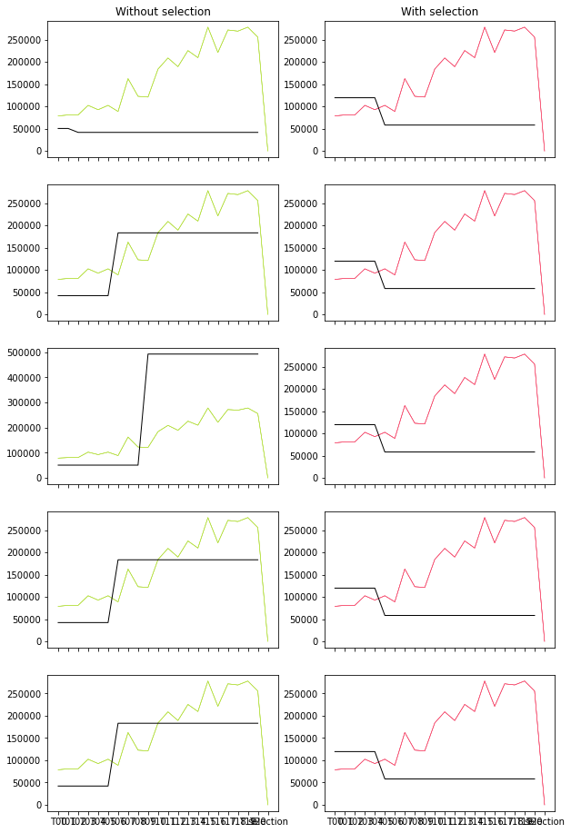

```python
fig, axs = plt.subplots(5, 2, figsize=(10, 16), sharex=True)
for i, (ns, s) in enumerate(zip(random_test_scenarios_no_sel, random_test_scenarios_sel)):
    plot_scenario(ns, df_best2, c="#A8DB1B", ax=axs[i][0])
    plot_scenario(s, df_best2, c="#F72851", ax=axs[i][1])
axs[0][0].set_title("Without selection")
axs[0][1].set_title("With selection")
```

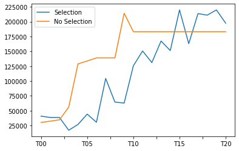

```python
RMSE(df_best2[df_best2.selection].drop(["selection"], axis=1)).groupby("scenario_idx").mean().mean().plot(label="Selection")
RMSE(df_best2[df_best2.selection==False].drop(["selection"], axis=1)).groupby("scenario_idx").mean().mean().plot(label="No Selection")
plt.legend()
```

# Create you own network with plugins

## Network plugin

We've used an architecture that already exist, but you can create your own network in [pytorch](https://pytorch.org/tutorials/beginner/basics/buildmodel_tutorial.html). The only difference compared to strictly pytorch network, is that your network object does not inherit from `torch.nn.Module` but from `dnadna.nets.Network`. This is a base class used to let `dnadna` knows that a this network exists.

```python
%%writefile mynet.py

import torch
import torch.nn.functional as F
from torch.nn.functional import relu
from torch import nn
from dnadna.nets import Network

class MyCNN(Network):
    def __init__(self, n_features, n_outputs):
        super().__init__()
        self.conv1 = nn.Conv2d(1, n_features, kernel_size=3, stride=2, bias=False)
        self.bn1 = nn.BatchNorm2d(n_features)
        self.pool = nn.MaxPool2d(2, 2)

        self.conv2 = nn.Conv2d(n_features, 20, kernel_size=3, stride=2, bias=False)
        self.fc1 = nn.Linear(480, 5)  # constraint for 400 snp and 50 indiv.
        self.fc2 = nn.Linear(5, n_outputs)

    def forward(self, x):
        batch_size = x.size(0)
        x = x.unsqueeze(1)
        x = self.pool(relu(self.conv1(x)))
        x = self.bn1(x)
        x = self.pool(relu(self.conv2(x)))
        x = x.view(batch_size, -1)  # flatten the tensor for each batch element
        x = relu(self.fc1(x))
        x = self.fc2(x)
        return x
```

```
Writing mynet.py
```

**Ask yourself what are conv layers, fc layers, relu and pooling operations?** There is a BUG, ON PURPOSE, in this code, you will get an error when running `!dnadna train ...` in the next section ("dnadna train with plugins") It seems that the dimensions are not correct (ie there's a discordance between the output of a layer and the required output of the next. You can use `!dnadna train ... --debug` to get more information and try to debug by updating the my_net file

## Transformation plugin

We can also create transformation plugins if you want to apply a particular transformation.

Below you can write your own, or try to write a transformation that randomize the individuals.

```python
%%writefile mytransform.py

from dnadna.transforms import Transform

class MyTransform(Transform):
    def __call__(self, data):
        sample, lp, scen = data
        snp, pos = sample.snp, sample.pos

        <Create you own transformation here>

        sample = sample.copy_with(snp=snp, pos=pos)
        return (sample, lp, scen)
```

**Help if you do not know where to start: You can see an example in mytransform_exampleA.py** Which can be added to the training config file within the `dataset_transforms` section dataset_transforms: - crop: max_snp: 400 max_indiv: 50 keep_polymorphic_only: true - mytransfom_exampleA - snp_format: concat - validate_snp: uniform_shape: false And then applied during training thanks to the plugin mode: `!dnadna train DLModel/DLModel_training_config.yml --plugin mytransform_exampleA.py`

**What is mytransform_exampleA doing?** Is it useful for CustomCNN training? And for an exchangeable network like SPIDNA?

## `dnadna train` with plugins

Don't forget to **change the name** of the network and parameters (`n_features: 5`) in the training config file ! Same for your transformation

e.g in the training config file:

```
# name and parameters of the neural net model to train
network:
    name: MyCNN

    # net parameters for CNN
    params:
        n_features: 5
```

```python
!dnadna train DLModel/DLModel_training_config.yml --plugin mytransform.py --plugin mynet.py
```

[output not shown]

[output cut: 189 more lines]

```

2022-06-14 01:42:18;     INFO;  Done

2022-06-14 01:42:18;     INFO;  --- 12.017512798309326 seconds ---
2022-06-14 01:42:18;     INFO;  --- Best loss: 0.336147665977478
2022-06-14 01:42:18;     INFO;  Saving model to "/home/fjay/Documents/WORK/Teaching/PSL/tuto-PSL/WorkshopDNADNA/DLModel/run_019/DLModel_run_019_last_epoch_net.pth" ...
2022-06-14 01:42:18;     INFO;  If tensorboard is installed, you can keep track of all training and validation losses by running the command:
2022-06-14 01:42:18;     INFO;      tensorboard --logdir /home/fjay/Documents/WORK/Teaching/PSL/tuto-PSL/WorkshopDNADNA/DLModel &
2022-06-14 01:42:18;     INFO;
2022-06-14 01:42:18;     INFO;  or display the current run only:
2022-06-14 01:42:18;     INFO;      tensorboard --logdir /home/fjay/Documents/WORK/Teaching/PSL/tuto-PSL/WorkshopDNADNA/DLModel/run_019
2022-06-14 01:42:18;     INFO;
2022-06-14 01:42:18;     INFO;  You can test the model's predictions on a test dataset by running the command:
2022-06-14 01:42:18;     INFO;
2022-06-14 01:42:18;     INFO;      dnadna predict /home/fjay/Documents/WORK/Teaching/PSL/tuto-PSL/WorkshopDNADNA/DLModel/run_019/DLModel_run_019_best_net.pth <dataset config file or paths to .npz files>
```

!dnadna train DLModel/DLModel_training_config.yml --plugin mytransform_exampleA.py --plugin mynet_exampleA.py

## Inspect your network

While developping, it can be useful to test how some part of the network performs.

**Comment the figures you have below**

```python
%run mynet.py # execute this such that you can instantiate the net class you created
```

```python
# %run mynet_exampleA.py # execute this such that you can instantiate the net class you created
```

```python
net = MyCNN(5, 20)
```

```python
snp_sample = SNPSample.from_file(DATAPATH + "/scenario_00001/BacterialDemoSelection_00001_000.npz")
```

```python
snp_sample.tensor.shape
```

```
torch.Size([601, 837])
```

```python
x = snp_sample.tensor.type(torch.float)
x = net.conv1(x.view(1, 1, 601, 837)) # add a batch dimension and a feature dimension before passing through conv1
print('output tensor size:', x.shape)
```

```
output tensor size: torch.Size([1, 5, 300, 418])
```

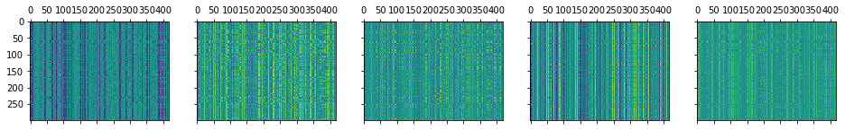

```python
fig, ax = plt.subplots(1, 5, figsize=(16, 8), sharey=True)
for i, f in enumerate(x[0].detach().numpy()):
    ax[i].matshow(f, vmin=x.min(), vmax=x.max())
```

```python
import dnadna.prediction as pred
```

Load a trained CNN net, the one from the plugin.

```python
p = pred.Predictor.from_net_file("<path_to_best_CNN_net.pth>")
```

```python
# Example
p = pred.Predictor.from_net_file("DLModel/run_000/DLModel_run_000_best_net.pth")
```

```python
# Overlook architecture
p.net
```

```
CustomCNN(
  (conv1): ModuleList(
    (0): Conv1d(1, 5, kernel_size=(2,), stride=(1,))
    (1): Conv1d(1, 5, kernel_size=(4,), stride=(1,))
    (2): Conv1d(1, 5, kernel_size=(8,), stride=(1,))
    (3): Conv1d(1, 5, kernel_size=(10,), stride=(1,))
    (4): Conv1d(1, 5, kernel_size=(1,), stride=(1,))
  )
  (batch_norm1): ModuleList(
    (0): BatchNorm1d(5, eps=1e-05, momentum=0.1, affine=True, track_running_stats=True)
    (1): BatchNorm1d(5, eps=1e-05, momentum=0.1, affine=True, track_running_stats=True)
    (2): BatchNorm1d(5, eps=1e-05, momentum=0.1, affine=True, track_running_stats=True)
    (3): BatchNorm1d(5, eps=1e-05, momentum=0.1, affine=True, track_running_stats=True)
    (4): BatchNorm1d(5, eps=1e-05, momentum=0.1, affine=True, track_running_stats=True)
  )
  (conv2): ModuleList(
    (0): Conv2d(1, 20, kernel_size=(2, 2), stride=(1, 1))
    (1): Conv2d(1, 20, kernel_size=(5, 4), stride=(1, 1))
    (2): Conv2d(1, 20, kernel_size=(3, 8), stride=(1, 1))
    (3): Conv2d(1, 20, kernel_size=(2, 10), stride=(1, 1))
    (4): Conv2d(1, 20, kernel_size=(20, 1), stride=(1, 1))
  )
  (batch_norm2): ModuleList(
    (0): BatchNorm2d(20, eps=1e-05, momentum=0.1, affine=True, track_running_stats=True)
    (1): BatchNorm2d(20, eps=1e-05, momentum=0.1, affine=True, track_running_stats=True)
    (2): BatchNorm2d(20, eps=1e-05, momentum=0.1, affine=True, track_running_stats=True)
    (3): BatchNorm2d(20, eps=1e-05, momentum=0.1, affine=True, track_running_stats=True)
    (4): BatchNorm2d(20, eps=1e-05, momentum=0.1, affine=True, track_running_stats=True)
  )
  (conv3): ModuleList(
    (0): Conv2d(1, 50, kernel_size=(385, 1), stride=(1, 1))
    (1): Conv2d(1, 50, kernel_size=(325, 1), stride=(1, 1))
    (2): Conv2d(1, 50, kernel_size=(365, 1), stride=(1, 1))
    (3): Conv2d(1, 50, kernel_size=(385, 1), stride=(1, 1))
    (4): Conv2d(1, 50, kernel_size=(25, 1), stride=(1, 1))
  )
  (batch_norm3): ModuleList(
    (0): BatchNorm2d(50, eps=1e-05, momentum=0.1, affine=True, track_running_stats=True)
    (1): BatchNorm2d(50, eps=1e-05, momentum=0.1, affine=True, track_running_stats=True)
    (2): BatchNorm2d(50, eps=1e-05, momentum=0.1, affine=True, track_running_stats=True)
    (3): BatchNorm2d(50, eps=1e-05, momentum=0.1, affine=True, track_running_stats=True)
    (4): BatchNorm2d(50, eps=1e-05, momentum=0.1, affine=True, track_running_stats=True)
  )
  (conv4): Conv2d(1, 50, kernel_size=(250, 1), stride=(1, 1))
  (batch_norm4): BatchNorm2d(50, eps=1e-05, momentum=0.1, affine=True, track_running_stats=True)
  (conv5): Conv2d(1, 50, kernel_size=(50, 3), stride=(3, 3))
  (batch_norm5): BatchNorm2d(50, eps=1e-05, momentum=0.1, affine=True, track_running_stats=True)
  (conv6): Conv2d(1, 50, kernel_size=(50, 3), stride=(3, 3))
  (batch_norm6): BatchNorm2d(50, eps=1e-05, momentum=0.1, affine=True, track_running_stats=True)
  (conv7): Conv2d(1, 50, kernel_size=(50, 3), stride=(3, 3))
  (batch_norm7): BatchNorm2d(50, eps=1e-05, momentum=0.1, affine=True, track_running_stats=True)
  (conv8): Conv2d(1, 50, kernel_size=(50, 3), stride=(3, 3))
  (batch_norm8): BatchNorm2d(50, eps=1e-05, momentum=0.1, affine=True, track_running_stats=True)
  (fc1): Linear(in_features=200, out_features=50, bias=True)
  (batch_norm9): BatchNorm1d(50, eps=1e-05, momentum=0.1, affine=True, track_running_stats=True)
  (fc2): Linear(in_features=50, out_features=21, bias=True)
)
```

```python
x = snp_sample.tensor.type(torch.float)
# The following works only if conv1 had been used by this  trained CNN
x2 = p.net.conv1(x.view(1, 1, 601, 837))
```

```python
fig, ax = plt.subplots(1, 5, figsize=(16, 8), sharey=True)
for i, f in enumerate(x2[0].detach().numpy()):
    ax[i].matshow(f, vmin=x2.min(), vmax=x2.max())
```

[output not shown]

```python
fig, ax = plt.subplots(1, 5, figsize=(16, 8), sharey=True)
for i, f in enumerate(net.conv1.weight):
    ax[i].matshow(f.squeeze().detach().numpy())
```

[output not shown]

```python
fig, ax = plt.subplots(1, 5, figsize=(16, 8), sharey=True)
for i, f in enumerate(p.net.conv1.weight):
    ax[i].matshow(f.squeeze().detach().numpy())
```

[output not shown]